# Telco Company Customer Churn Analysis

### 2. Explortary Data Analysis

#### 2.1 Churn Rate Overview

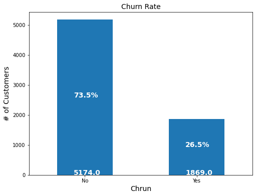

```python
churn_rate = telecom_cust['Churn'].value_counts()
ax = churn_rate.plot(kind = 'bar',stacked = True, rot = 0, figsize = (8,6))
#ax.yaxis.set_major_formatter(mtick.PercentFormatter())
ax.set_xlabel('Chrun', size = 14)
ax.set_ylabel('# of Customers', size = 14)
ax.set_title('Churn Rate', size = 14)
totals = []
for i in ax.patches:
     totals.append(i.get_height())

total = sum(totals)
for p in ax.patches:
     width, height = p.get_width(), p.get_height()
     x,y = p.get_xy()
     ax.annotate('{:.1f}%'.format(height/total*100),
                 (x+0.3*width,height*0.5),
                 color = 'white',
                 weight = 'bold',
                 size = 14)
     ax.annotate('{:.1f}'.format(height),
                 (x+0.3*width, y),
                 color = 'white',
                 weight = 'bold',
                 size = 14)
```

There were 26.5% customer churning in the last month.

#### 2.2 Churning Customer Distribution in Gender and Age

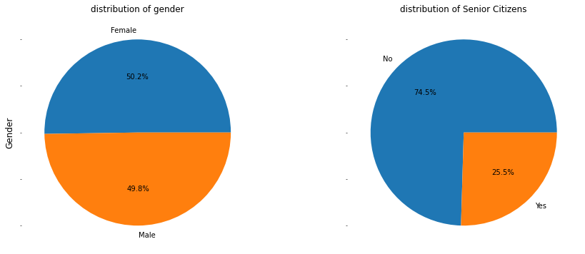

```python
fig,(ax1,ax2) = plt.subplots(nrows=1, ncols=2, sharey=True, figsize= (15,6))
temp = telecom_cust.gender[telecom_cust['Churn'] == 'Yes']
temp.replace(0,'Female',inplace = True)
temp.replace(1,'Male',inplace = True)
a_counts = temp.value_counts()
total_num = len(temp)
ax1 = (a_counts*100/total_num).plot.pie(labels=['Female','Male'],fontsize = 10,ax = ax1,autopct='%1.1f%%')
ax1.yaxis.set_major_formatter(mtick.PercentFormatter())
ax1.set_ylabel('Gender', fontsize = 12)
ax1.set_title('distribution of gender')

b_counts = telecom_cust.SeniorCitizen[telecom_cust['Churn'] == 'Yes'].value_counts()
ax2 = (b_counts*100/total_num).plot.pie(labels=['No','Yes'],fontsize = 10,ax = ax2,autopct='%1.1f%%')
ax2.yaxis.set_major_formatter(mtick.PercentFormatter())
ax2.set_ylabel('Senior Citizens', fontsize = 12)
ax2.set_title('distribution of Senior Citizens')
```

The churning customers are distributed evenly in females and males, and most of them are young generation. However, the distribution may be affected by original consumer features, so the reason for the large proportion of young citizens in churning customers may be that the majority of customers in this telco company are young. In order to look into an accurate and unbiased changing pattern, we need to check the variety of retention within each group.

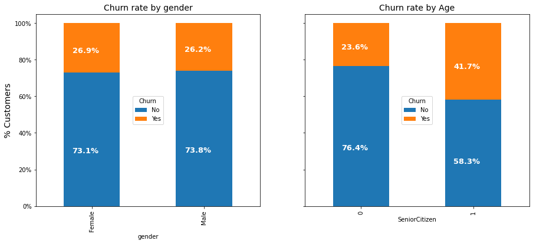

```python
gender_churn = telecom_cust.groupby(['gender','Churn']).size().unstack()
SeniorCitizen_churn = telecom_cust.groupby(['SeniorCitizen','Churn']).size().unstack()

fig,(ax1,ax2) = plt.subplots(nrows=1, ncols=2, sharey=True, figsize= (15,6))
ax= (gender_churn.T/gender_churn.T.sum()*100).T.plot(kind= 'bar',stacked=True,ax=ax1)
#adjust fig
ax.yaxis.set_major_formatter(mtick.PercentFormatter())
ax.legend(loc= 'center',title= 'Churn')
ax.set_ylabel('% Customers', size= 14)
ax.set_title('Churn rate by gender', size= 14)
#add data labels
for p in ax.patches:
    width, height=p.get_width(),p.get_height()
    x,y=p.get_xy()
    ax.annotate('{:.1f}%'.format(height),
            (x+0.15*width,y+0.4*height),
            color= 'white',
            weight= 'bold',
            size= 13)

ax= (SeniorCitizen_churn.T/SeniorCitizen_churn.T.sum()*100).T.plot(kind= 'bar',stacked=True,ax=ax2)
#adjust fig
ax.yaxis.set_major_formatter(mtick.PercentFormatter())
ax.legend(loc= 'center',title= 'Churn')
ax.set_ylabel('% Customers', size= 14)
ax.set_title('Churn rate by Age', size= 14)
#add data labels
for p in ax.patches:
    width, height=p.get_width(),p.get_height()
    x,y=p.get_xy()
    ax.annotate('{:.1f}%'.format(height),
            (x+0.15*width,y+0.4*height),
            color= 'white',
            weight= 'bold',
            size= 13)
```

Although the young generation takes up a large proportion of churning customers, there were 41.7% senior citizens churning last month, which is way more than the churning percentage among young citizens (23.6%).

#### 2.3 Churn rate by dependency

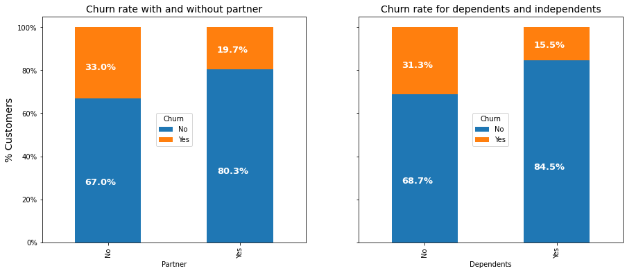

```python
partner_churn = telecom_cust.groupby(['Partner','Churn']).size().unstack()
dependent_churn = telecom_cust.groupby(['Dependents','Churn']).size().unstack()

fig,(ax1,ax2) = plt.subplots(nrows=1, ncols=2, sharey=True, figsize= (15,6))
ax= (partner_churn.T/partner_churn.T.sum()*100).T.plot(kind= 'bar',stacked=True,ax=ax1)
#adjust fig
ax.yaxis.set_major_formatter(mtick.PercentFormatter())
ax.legend(loc= 'center',title= 'Churn')
ax.set_ylabel('% Customers', size= 14)
ax.set_title('Churn rate with and without partner', size= 14)
#add data labels
for p in ax.patches:
    width, height=p.get_width(),p.get_height()
    x,y=p.get_xy()
    ax.annotate('{:.1f}%'.format(height),
            (x+0.15*width,y+0.4*height),
            color= 'white',
            weight= 'bold',
            size= 13)

ax= (dependent_churn.T/dependent_churn.T.sum()*100).T.plot(kind= 'bar',stacked=True,ax=ax2)
#adjust fig
ax.yaxis.set_major_formatter(mtick.PercentFormatter())
ax.legend(loc= 'center',title= 'Churn')
ax.set_ylabel('% Customers', size= 14)
ax.set_title('Churn rate for dependents and independents', size= 14)
#add data labels
for p in ax.patches:
    width, height=p.get_width(),p.get_height()
    x,y=p.get_xy()
    ax.annotate('{:.1f}%'.format(height),
            (x+0.15*width,y+0.4*height),
            color= 'white',
            weight= 'bold',
            size= 13)
```

Customers who have no partner or who are independents are easier to churn.

#### 2.4 Chur rate and Tenture

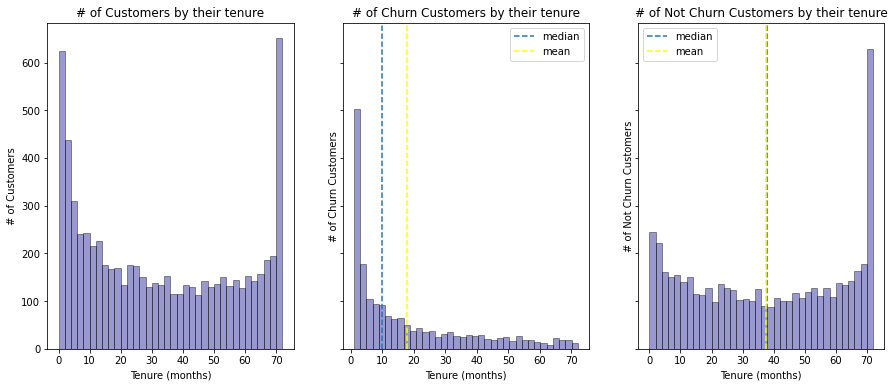

```python
fig,(ax1,ax2,ax3) = plt.subplots(nrows = 1, ncols=3, sharey=True, figsize = (15,6))
ax = sns.distplot(telecom_cust['tenure'],hist=True, kde = False,
 bins = 36,
 color= 'darkblue',hist_kws={'edgecolor':'black'},
 kde_kws={'linewidth':4},
 ax = ax1)
ax.set_ylabel('# of Customers')
ax.set_xlabel('Tenure (months)')
ax.set_title('# of Customers by their tenure')
x = telecom_cust.tenure[telecom_cust['Churn'] == 'Yes']
ax = sns.distplot(x,hist=True, kde = False,
 bins = 36,
 color= 'darkblue',hist_kws={'edgecolor':'black'},
 kde_kws={'linewidth':4},
 ax = ax2)
ax.set_ylabel('# of Churn Customers')
ax.set_xlabel('Tenure (months)')
ax.set_title('# of Churn Customers by their tenure')
ax.axvline(x.median(),linestyle = '--')
ax.axvline(x.mean(),linestyle = '--',color = 'yellow')
ax.legend(['median','mean'],loc = 'upper right')
x = telecom_cust.tenure[telecom_cust['Churn'] == 'No']
ax = sns.distplot(x,hist=True, kde = False,
 bins = 36,
 color= 'darkblue',hist_kws={'edgecolor':'black'},
 kde_kws={'linewidth':4},
 ax = ax3)
ax.axvline(x.median(),linestyle = '--')
ax.axvline(x.mean(),linestyle = '--',color = 'yellow')
ax.legend(['median','mean'],loc = 'upper left')
ax.set_ylabel('# of Not Churn Customers')
ax.set_xlabel('Tenure (months)')
ax.set_title('# of Not Churn Customers by their tenure')
```

- Churning customers tend to have shorter tenure, and the medium tenure for churning customers is less than 20 months.
- Retention customers have much more even distribution in tenure between zero to sixties months, while many people have 72 months tenure. The medium tenure for retention customers is around 40 months, which is twice more than churning customers'.

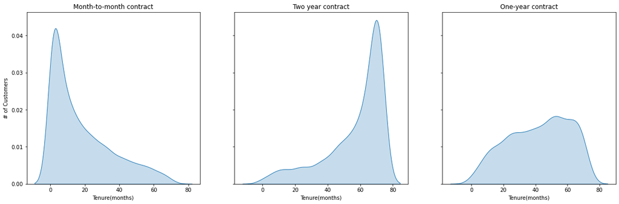

```python
#subplot
fig,(ax1,ax2,ax3) = plt.subplots(nrows = 1, ncols=3, sharey=True, figsize = (20,6))
#plot 1 conditional subset's count: telecom_cust[telecom_cust['Contract']=='Month-to-month']
ax = sns.kdeplot(telecom_cust[telecom_cust['Contract']=='Month-to-month']['tenure'],
 shade=True,
 ax=ax1)
ax.set_ylabel('# of Customers')
ax.set_xlabel('Tenure(months)')
ax.set_title('Month-to-month contract')
ax = sns.kdeplot(telecom_cust[telecom_cust['Contract']=='Two year']['tenure'],
 shade = True,
 ax=ax2)
ax.set_ylabel('# of Customers')
ax.set_xlabel('Tenure(months)')
ax.set_title('Two year contract')
ax = sns.kdeplot(telecom_cust[telecom_cust['Contract']=='One year']['tenure'],
 shade = True,
 ax=ax3)
ax.set_ylabel('# of Customers')
ax.set_xlabel('Tenure(months)')
ax.set_title('One-year contract')
```

#### 2.6 Churn Rate by Contract Type

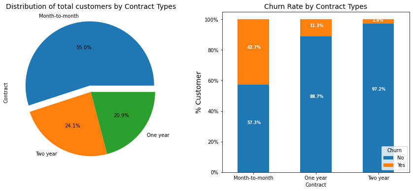

```python
fig,(ax1,ax2) = plt.subplots(nrows=1, ncols=2, sharey=False, figsize= (15,6))

counts = telecom_cust['Contract'].value_counts()
ax1 = (counts*100/total_num).plot.pie(ax = ax1,autopct='%1.1f%%',explode=(0.1, 0, 0))
ax1.yaxis.set_major_formatter(mtick.PercentFormatter())
ax1.set_title('Distribution of total customers by Contract Types',size = 14)


df1 = telecom_cust.groupby(['Churn','Contract']).size().unstack()
df2 = df1/df1.sum()*100
ax2 = df2.T.plot(kind = 'bar', stacked = True, rot = 0, ax = ax2)
ax2.yaxis.set_major_formatter(mtick.PercentFormatter())
ax2.set_ylabel('% Customer', size = 14)
ax2.set_title('Churn Rate by Contract Types', size = 14)
for p in ax2.patches:
     width, height = p.get_width(),p.get_height()
     x,y = p.get_xy()
     ax2.annotate('{:.1f}%'.format(height),
     (x+0.3*width,y+0.55*height),
     color = 'white',
     weight = 'bold',
     size = 8)

ax2.legend(loc = 'lower right',title = 'Churn')
```

Short-term contract customers take up 55% of total customers, but almost half of Month-to-Month contract customers churned last month, while long-term contract customers are relatively more stable. There were 11.3% churning in one-year contract customers and 2.8% churning in two-year contract customers.